# Part II - (Effect Of Loan Characteristics To Predict Borrower's APR)

## Investigation Overview

In this investigation, I wanted to look at the characteristics of Loan that could be used to predict their Borrower's APR. The main focus was on the following things: LoanOriginalamount Prosper rating (Alpha) Term Stated Monthly Income

## Dataset Overview

This dataset is financial dataset and this is related to the loan, borrowers, lenders, interest rates and stuffs like that. Prosper or Prosper Marketplace Inc. is a San Francisco, California based company specializing in loans at low interest rates to the borrowers. In this dataset, we are using the data from the Posper to analyse it and trying to find the pattern in the Prosper data.

This dataset contains information about loan listings and related variables including borrower as well as lender information. It contains variables related to Borrower such as credit rating, prosper rating etc. Moreover, the dataset also has lender information.

# Distribution of Borrower APR(The Borrower's Annual percentage Rate)

The distribution of APR looks multimodal. A small peak is centered at 0.1, a larger peak centered at 0.2. There is also a small peak centered 0.3. Additionally, there is a very sharp peak between 0.35 and 0.36. Only very few loans have APR greater than 0.45.

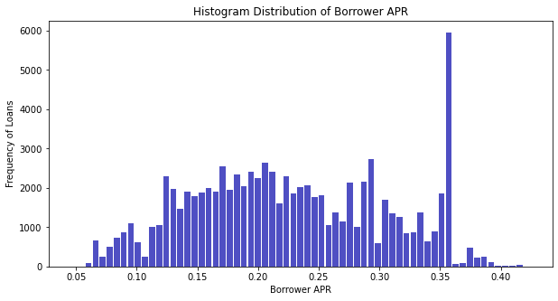

# LoanStatus(completed,Defaulted,Cancelled,Chargedoff):

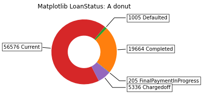

# Effect of Loan Amount on Borrower's APR)

By observing the above plot we can infer that with rising Loan amount the value of APR is decreasing.Overall, the borrower APR is negatively correlated with loan amount.

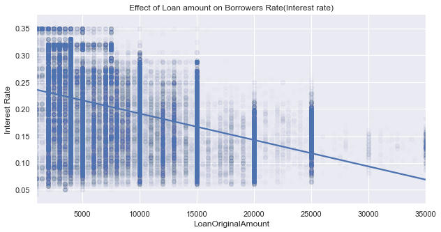

# Effect of Term on ProsperRating:

we can see below that there is a interaction between term and Prosper rating. Proportionally, there are more 60 month loans on B and C ratings. We can also infer from above plot that ProsperRating (Prosper rating represents an estimated average annualized loss rate range to the investor) in this loandata set is mostly for a period of 36(3 years) months loan Term.Beside that we can see that prosper rating 'A' (according to Prosper loan system,Estimated average annual loss rate of 2.00–3.99%)is highest in 36 months term.

[figure not shown]

# Effect of ProsperRating on Borrowers APR and Loanamount:

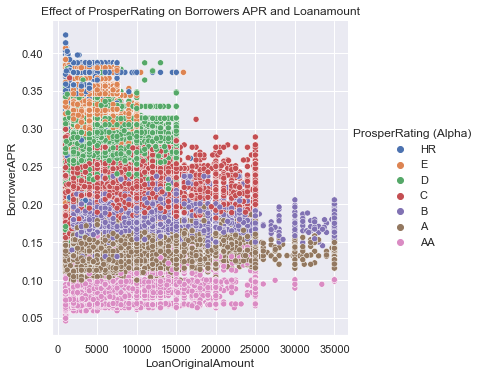

# Effect of Term on Borrower's APR and Loanamount:

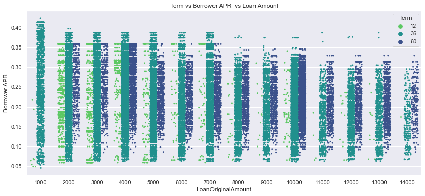